# Quotes Analysis EDA 1

#### 6. **Quote Amounts**

- **Question**: How do different quote amounts (e.g., over $20,000 or under $2,000) affect win rates?
- **Analysis**:
  - **Insight**:Smaller quote amounts ($0 to $2000) have the highest win rates, followed by mid-range ($2000 to $20000) and high-value quotes ($20000+). This suggests that lower-value quotes are more likely to succeed. Adjust pricing and sales strategies accordingly.

```
Stage                0.0   1.0   2.0  Win_Quantity  Loss_Quantity  \
Value_Bin
(0.0, 2000.0]      10406  5494  4126          5494          10406
(2000.0, 20000.0]   5341  1929  2331          1929           5341
(20000.0, inf]       797   128   341           128            797

Stage              Open_Quantity  Win_Rate  Loss_Rate  Open_Rate
Value_Bin
(0.0, 2000.0]               4126  0.274343   0.519624   0.206032
(2000.0, 20000.0]           2331  0.200917   0.556296   0.242787
(20000.0, inf]               341  0.101106   0.629542   0.269352
```

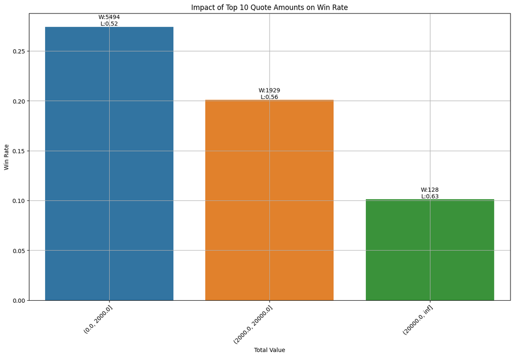

```python
def analyze_quote_amount_impact(data, feature_name='Total Value', target_name='Stage', bins=[0, 2000, 20000, np.inf]):
    data['Value_Bin'] = pd.cut(data[feature_name], bins)
    impact = data.groupby(['Value_Bin', target_name]).size().unstack().fillna(0)
    impact['Win_Quantity'] = impact[1.0]
    impact['Loss_Quantity'] = impact[0.0]
    impact['Open_Quantity'] = impact[2.0]
    impact['Win_Rate'] = impact[1.0] / (impact[1.0] + impact[0.0] + impact[2.0])
    impact['Loss_Rate'] = impact[0.0] / (impact[1.0] + impact[0.0] + impact[2.0])
    impact['Open_Rate'] = impact[2.0] / (impact[1.0] + impact[0.0] + impact[2.0])
    return impact.sort_values(by=['Win_Quantity', 'Win_Rate'], ascending=[False, False])

quote_amount_impact = analyze_quote_amount_impact(data_dropped).head(10)
print(quote_amount_impact)
plot_impact(quote_amount_impact, 'Total Value', 'Top 10 Quote Amounts')
```

#### 7. **States**

- **Question**: In which states does the client sell better?
- **Analysis**:
  - **Insight**: Some states show significantly higher win rates compared to others. States with higher win rates indicate a stronger market presence and customer preference. Focus marketing and sales efforts in these high-performing states to maximize success and leverage regional strengths.

```
Stage             0.0     1.0     2.0  Win_Quantity  Loss_Quantity  \
Sell-To State
OH             3502.0  1120.0  1581.0        1120.0         3502.0
IL              929.0   477.0   299.0         477.0          929.0
TX             1311.0   453.0   457.0         453.0         1311.0
PA              683.0   398.0   524.0         398.0          683.0
MI              505.0   390.0   182.0         390.0          505.0
CA              638.0   373.0   433.0         373.0          638.0
FL              703.0   363.0   244.0         363.0          703.0
NJ              441.0   305.0   203.0         305.0          441.0
NY              509.0   295.0   183.0         295.0          509.0
MA              610.0   272.0   232.0         272.0          610.0

Stage          Open_Quantity  Win_Rate  Loss_Rate  Open_Rate
Sell-To State
OH                    1581.0  0.180558   0.564566   0.254877
IL                     299.0  0.279765   0.544868   0.175367
TX                     457.0  0.203962   0.590275   0.205763
PA                     524.0  0.247975   0.425545   0.326480
MI                     182.0  0.362117   0.468895   0.168988
CA                     433.0  0.258310   0.441828   0.299861
FL                     244.0  0.277099   0.536641   0.186260
NJ                     203.0  0.321391   0.464700   0.213909
NY                     183.0  0.298886   0.515704   0.185410
MA                     232.0  0.244165   0.547576   0.208259
```

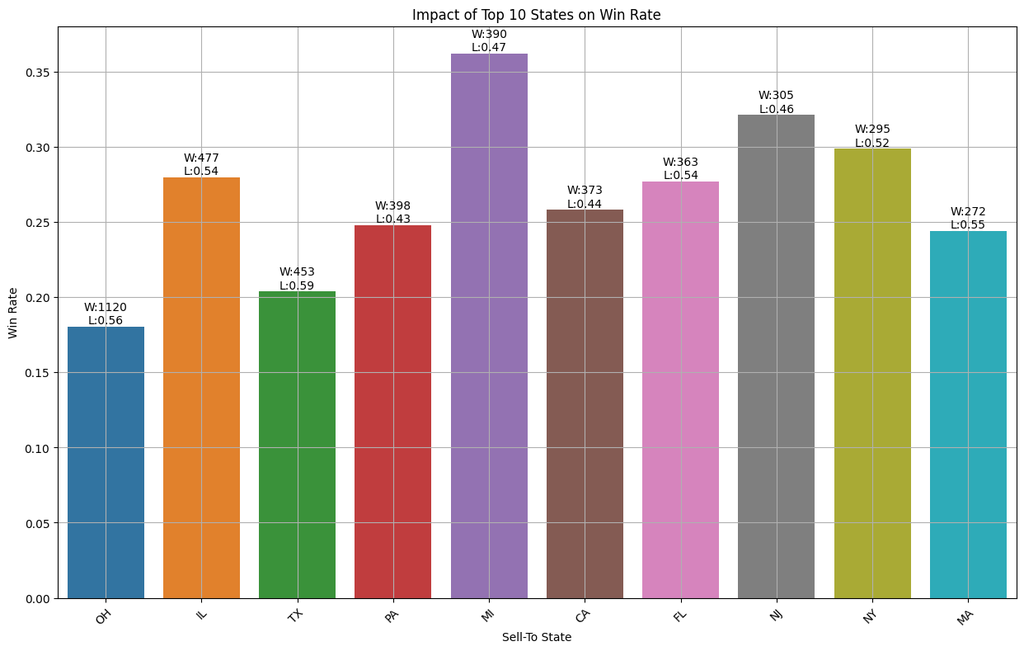

```python
def analyze_state_impact(data, feature_name='Sell-To State', target_name='Stage'):
    impact = data.groupby([feature_name, target_name]).size().unstack().fillna(0)
    impact['Win_Quantity'] = impact[1.0]
    impact['Loss_Quantity'] = impact[0.0]
    impact['Open_Quantity'] = impact[2.0]
    impact['Win_Rate'] = impact[1.0] / (impact[1.0] + impact[0.0] + impact[2.0])
    impact['Loss_Rate'] = impact[0.0] / (impact[1.0] + impact[0.0] + impact[2.0])
    impact['Open_Rate'] = impact[2.0] / (impact[1.0] + impact[0.0] + impact[2.0])
    return impact.sort_values(by=['Win_Quantity', 'Win_Rate'], ascending=[False, False])

state_impact = analyze_state_impact(data_dropped).head(10)
print(state_impact)
plot_impact(state_impact, 'Sell-To State', 'Top 10 States')
```

#### 8. **Quote Months**

- **Question**: Which months in the year does the client sell better?
- **Analysis**:
  - **Insight**: Certain months exhibit higher win rates, indicating seasonal trends in sales performance. Understanding these trends can help in planning promotional activities and resource allocation during peak months to enhance sales performance and customer engagement.

```
Stage         0.0  1.0   2.0  Win_Quantity  Loss_Quantity  Open_Quantity  \
Quote Month
Mar          1520  984  2082           984           1520           2082
Apr          1281  910  2087           910           1281           2087
May          1353  768  1178           768           1353           1178
Feb          2030  733  1112           733           2030           1112
Jan          2809  727   114           727           2809            114
Aug          1432  614    43           614           1432             43
Jun          1211  529    29           529           1211             29
Sep          1098  497    61           497           1098             61
Dec           890  494    90           494            890             90
Oct          1233  492    45           492           1233             45

Stage        Win_Rate  Loss_Rate  Open_Rate
Quote Month
Mar          0.214566   0.331444   0.453990
Apr          0.212716   0.299439   0.487845
May          0.232798   0.410124   0.357078
Feb          0.189161   0.523871   0.286968
Jan          0.199178   0.769589   0.031233
Aug          0.293921   0.685495   0.020584
Jun          0.299039   0.684568   0.016393
Sep          0.300121   0.663043   0.036836
Dec          0.335142   0.603799   0.061058
Oct          0.277966   0.696610   0.025424
```

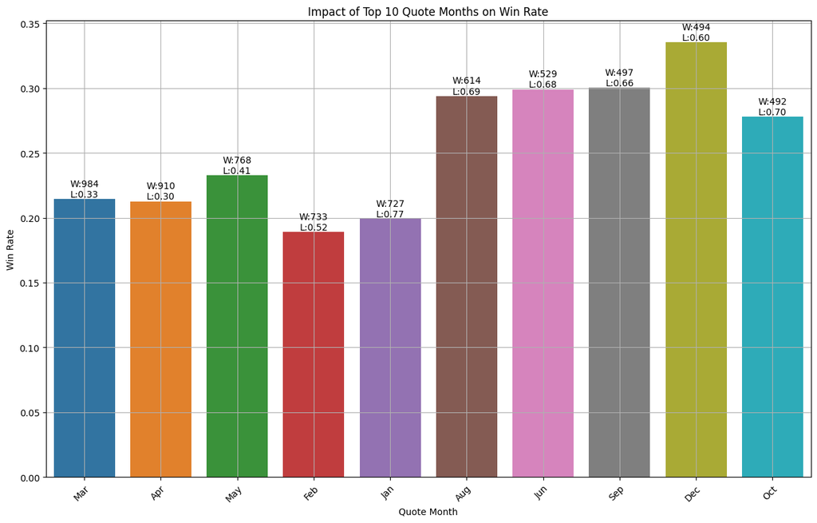

```python
def analyze_quote_month_impact(data, feature_name='Quote Month', target_name='Stage'):
    impact = data.groupby([feature_name, target_name]).size().unstack().fillna(0)
    impact['Win_Quantity'] = impact[1.0]
    impact['Loss_Quantity'] = impact[0.0]
    impact['Open_Quantity'] = impact[2.0]
    impact['Win_Rate'] = impact[1.0] / (impact[1.0] + impact[0.0] + impact[2.0])
    impact['Loss_Rate'] = impact[0.0] / (impact[1.0] + impact[0.0] + impact[2.0])
    impact['Open_Rate'] = impact[2.0] / (impact[1.0] + impact[0.0] + impact[2.0])
    return impact.sort_values(by=['Win_Quantity', 'Win_Rate'], ascending=[False, False])

quote_month_impact = analyze_quote_month_impact(data_dropped).head(10)
print(quote_month_impact)
plot_impact(quote_month_impact, 'Quote Month', 'Top 10 Quote Months')
```